Nada Ardelia  
G1401231011

# Library

```r
library(ggplot2)
library(tsibble)
library(tseries)
library(MASS)
```

```r
library(lattice)
library(dplyr)
```

```r
library(forecast)
library(TSA)
library(TTR)
library(aTSA)
library(graphics)
```

# Data

```r
data <- read.csv("C:\\Users\\ailed\\Downloads\\Telur Ayam Ras.csv")
head(data)
```

```
##         Date Jawa.Barat
## 1 2022-07-14      27680
## 2 2022-07-15      27920
## 3 2022-07-16      27960
## 4 2022-07-17      27890
## 5 2022-07-18      27950
## 6 2022-07-19      28260
```

```r
data_subset <- data[160:319, ]
head(data_subset)
```

```
##           Date Jawa.Barat
## 160 2022-12-20      30500
## 161 2022-12-21      30400
## 162 2022-12-22      30200
## 163 2022-12-23      29880
## 164 2022-12-24      29810
## 165 2022-12-25      30050
```

```r
data_subset$Date <- as.Date(data_subset$Date)
```

# Partisi Data

```r
n <- nrow(data_subset)
train_size <- floor(0.8 * n)

# Bagi data
train_data <- data_subset[1:train_size, ]
test_data  <- data_subset[(train_size+1):n, ]

# Cek jumlah baris
nrow(train_data)
```

```
## [1] 128
```

```r
nrow(test_data)
```

```
## [1] 32
```

## Data Train

```r
train_data$Date <- as.Date(train_data$Date)
```

### Plot Time Series

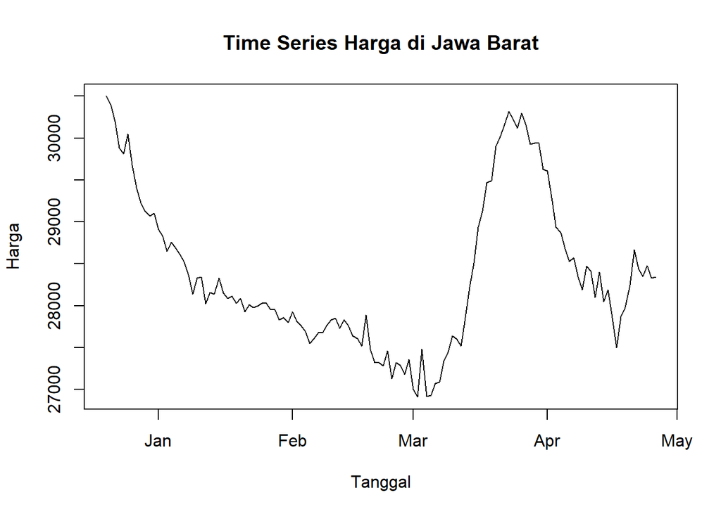

```r
plot(train_data$Date, train_data$Jawa.Barat, type = "l",
     xlab = "Tanggal", ylab = "Harga", main = "Time Series Harga di Jawa Barat")
```

```r
mean(train_data$Jawa.Barat, na.rm = TRUE)
```

```
## [1] 28369.69
```

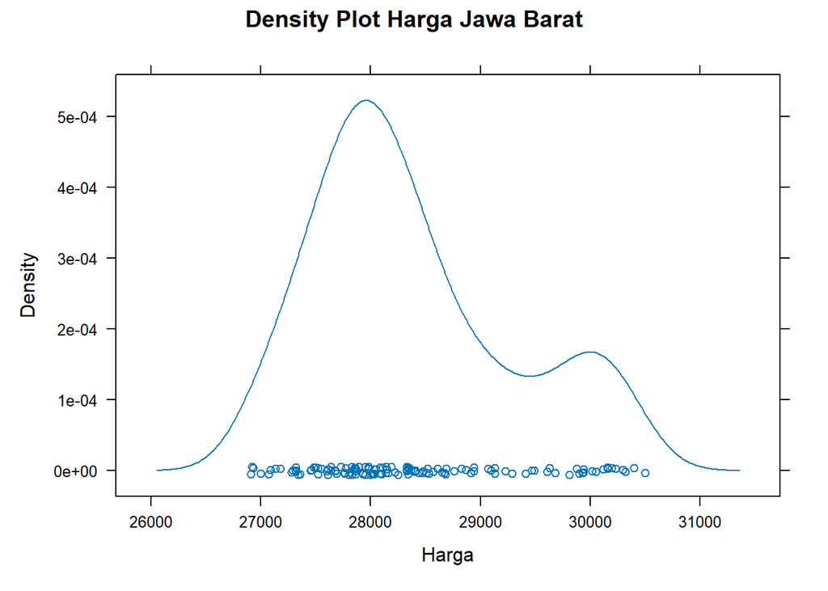

```r
densityplot(as.vector(train_data$Jawa.Barat),
            main = "Density Plot Harga Jawa Barat",
            xlab = "Harga")
```

### Plot ACF

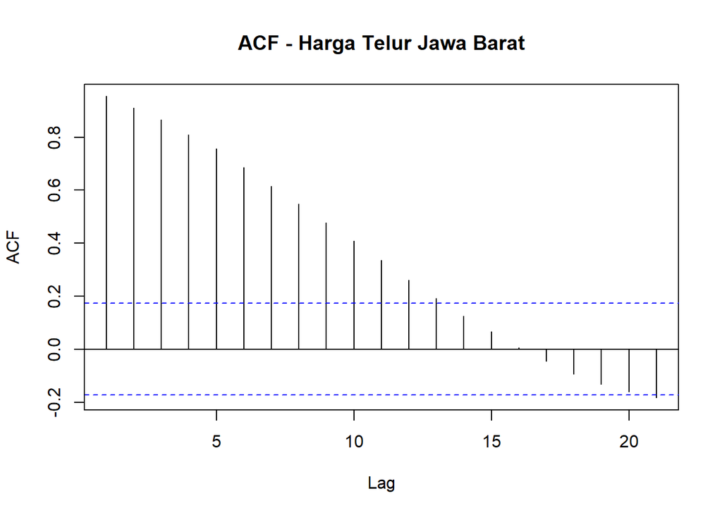

```r
harga_train <- na.omit(train_data$Jawa.Barat)
acf(harga_train, main = "ACF - Harga Telur Jawa Barat")
```

Berdasarkan plot ACF, terlihat bahwa plot ACF pada data tersebut cenderung tails off.

### Uji ADF

$H_0$: Data tidak stasioner dalam rataan

$H_1$: Data stasioner dalam rataan

```r
tseries::adf.test(harga_train)
```

```
##
##  Augmented Dickey-Fuller Test
##
## data:  harga_train
## Dickey-Fuller = -2.9681, Lag order = 5, p-value = 0.1741
## alternative hypothesis: stationary
```

### Plot Box Cox

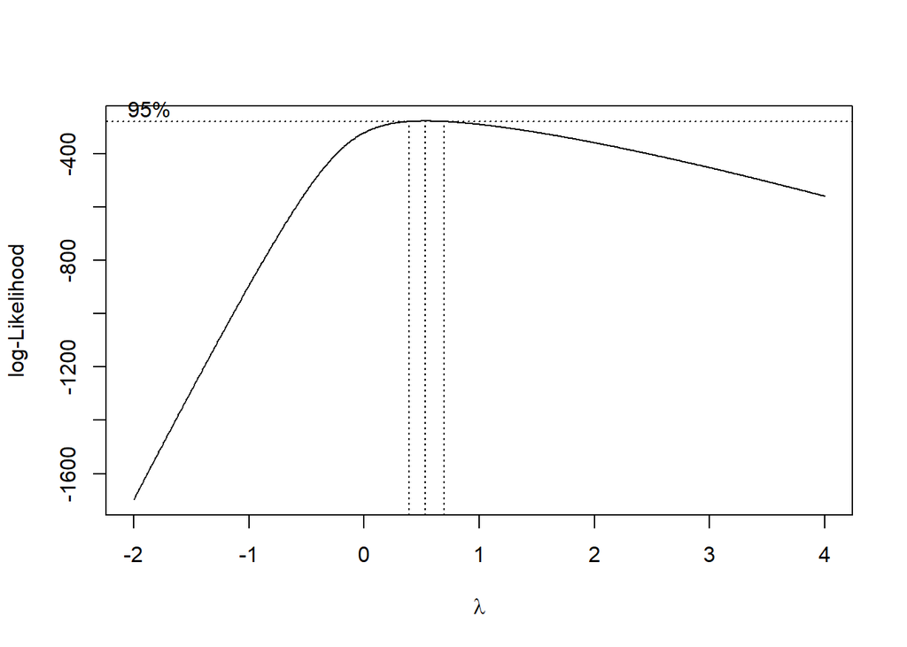

```r
index <- seq_along(harga_train)

# Plot Box-Cox
bc_train <- boxcox(harga_train - min(harga_train) + 1 ~ index, lambda = seq(-2, 4, by = 0.01))
```

```r
# Nilai lambda maksimum (optimum)
lambda_train <- bc_train$x[which.max(bc_train$y)]
lambda_train
```

```
## [1] 0.53
```

```r
# Hitung selang kepercayaan 95%

# CI lambda: nilai log-likelihood maksimum - chi-square
ci_lambda_train <- bc_train$x[bc_train$y > max(bc_train$y) - 0.5 * qchisq(0.95, 1)]

# Batas bawah dan atas
ci_lower_train <- min(ci_lambda_train)
ci_upper_train <- max(ci_lambda_train)

# Tampilkan hasil
c(Batas_Bawah = ci_lower_train, Batas_Atas = ci_upper_train)
```

```
## Batas_Bawah  Batas_Atas
##        0.39        0.69
```

Gambar di atas menunjukkan nilai λ optimum (rounded value) sebesar 0,53 dan selang kepercayaan 95% nilai memiliki batas bawah 0,39 dan batas atas 0,69. Selang tersebut *tidak memuat nilai satu* sehingga dapat dikatakan bahwa data harga *tidak stasioner dalam ragam*.

### Differencing 1

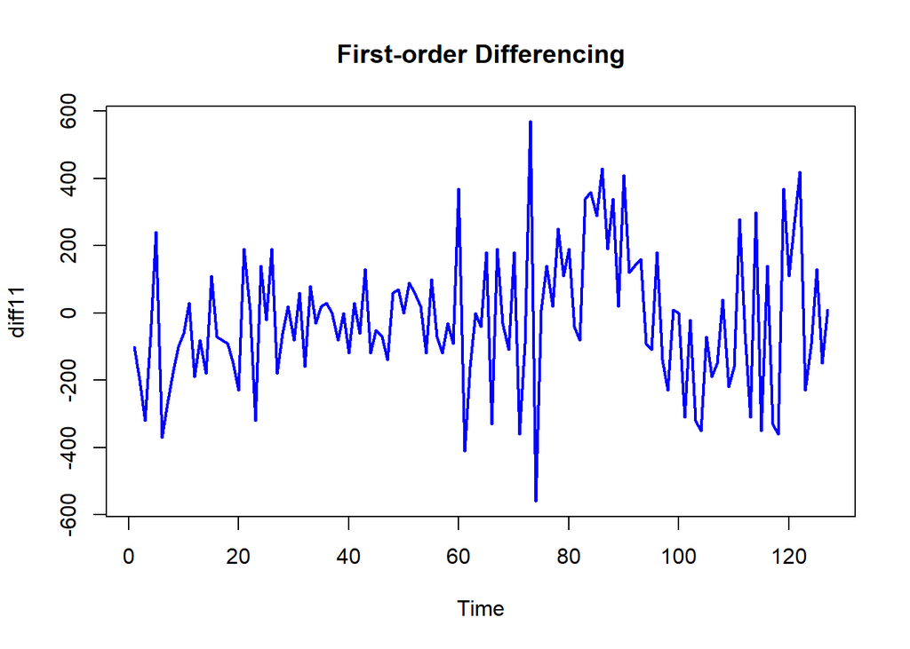

```r
diff11 <- diff(harga_train, differences = 1)
plot.ts(diff11, main = "First-order Differencing", col = "blue", lwd = 2)
```

```r
adf.test(diff11)
```

```
## Augmented Dickey-Fuller Test
## alternative: stationary
##
## Type 1: no drift no trend
##      lag    ADF p.value
## [1,]   0 -11.35    0.01
## [2,]   1  -6.98    0.01
## [3,]   2  -4.24    0.01
## [4,]   3  -4.06    0.01
## [5,]   4  -2.88    0.01
## Type 2: with drift no trend
##      lag    ADF p.value
## [1,]   0 -11.38  0.0100
## [2,]   1  -7.00  0.0100
## [3,]   2  -4.23  0.0100
## [4,]   3  -4.05  0.0100
## [5,]   4  -2.89  0.0511
## Type 3: with drift and trend
##      lag    ADF p.value
## [1,]   0 -11.57   0.010
## [2,]   1  -7.13   0.010
## [3,]   2  -4.24   0.010
## [4,]   3  -4.07   0.010
## [5,]   4  -2.93   0.187
## ----
## Note: in fact, p.value = 0.01 means p.value <= 0.01
```

### Differencing 2

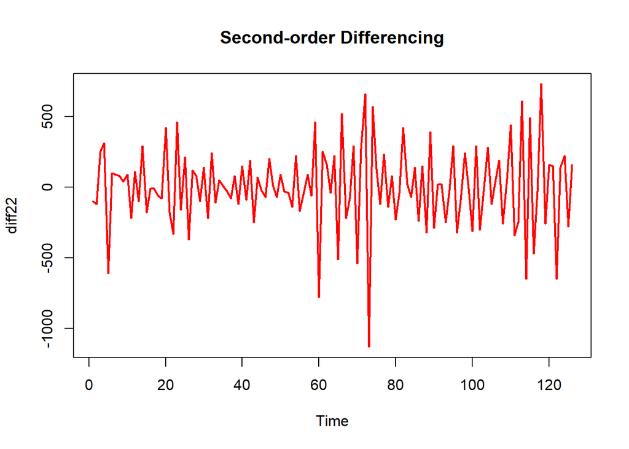

```r
diff22 <- diff(harga_train, differences = 2)
plot.ts(diff22, main = "Second-order Differencing", col = "red", lwd = 2)
```

```r
adf.test(diff22)
```

```
## Augmented Dickey-Fuller Test
## alternative: stationary
##
## Type 1: no drift no trend
##      lag    ADF p.value
## [1,]   0 -21.39    0.01
## [2,]   1 -18.01    0.01
## [3,]   2 -10.22    0.01
## [4,]   3 -10.24    0.01
## [5,]   4  -8.39    0.01
## Type 2: with drift no trend
##      lag    ADF p.value
## [1,]   0 -21.30    0.01
## [2,]   1 -17.94    0.01
## [3,]   2 -10.18    0.01
## [4,]   3 -10.20    0.01
## [5,]   4  -8.36    0.01
## Type 3: with drift and trend
##      lag    ADF p.value
## [1,]   0 -21.22    0.01
## [2,]   1 -17.88    0.01
## [3,]   2 -10.15    0.01
## [4,]   3 -10.15    0.01
## [5,]   4  -8.33    0.01
## ----
## Note: in fact, p.value = 0.01 means p.value <= 0.01
```

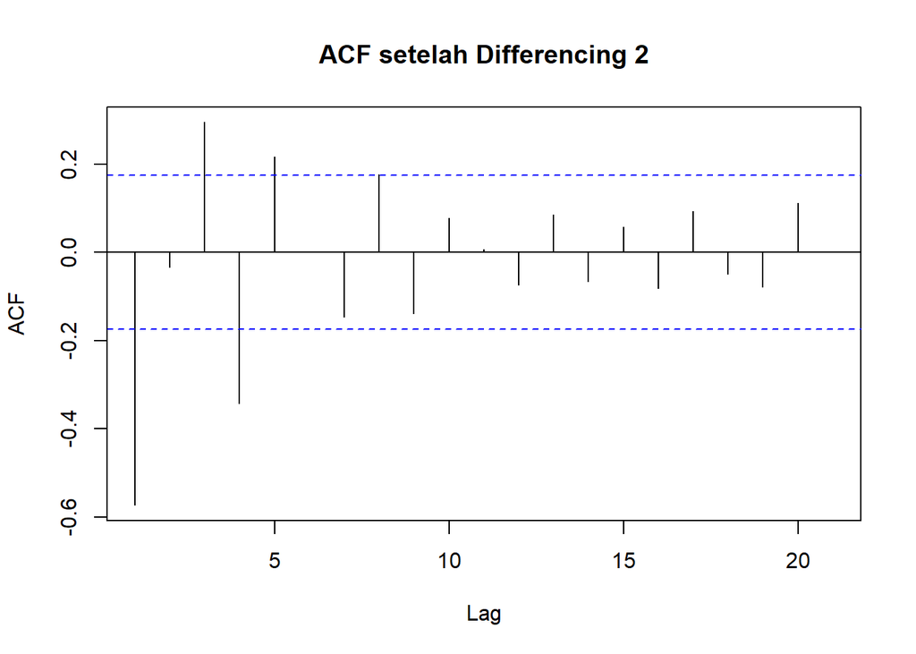

```r
acf(diff22, main = "ACF setelah Differencing 2")
```

Data sudah stasioner terhadap rataan.

```r
# Data digeser agar positif
diff22_train_geser <- diff22 - min(diff22) + 1
```

### Plot Box Cox 2

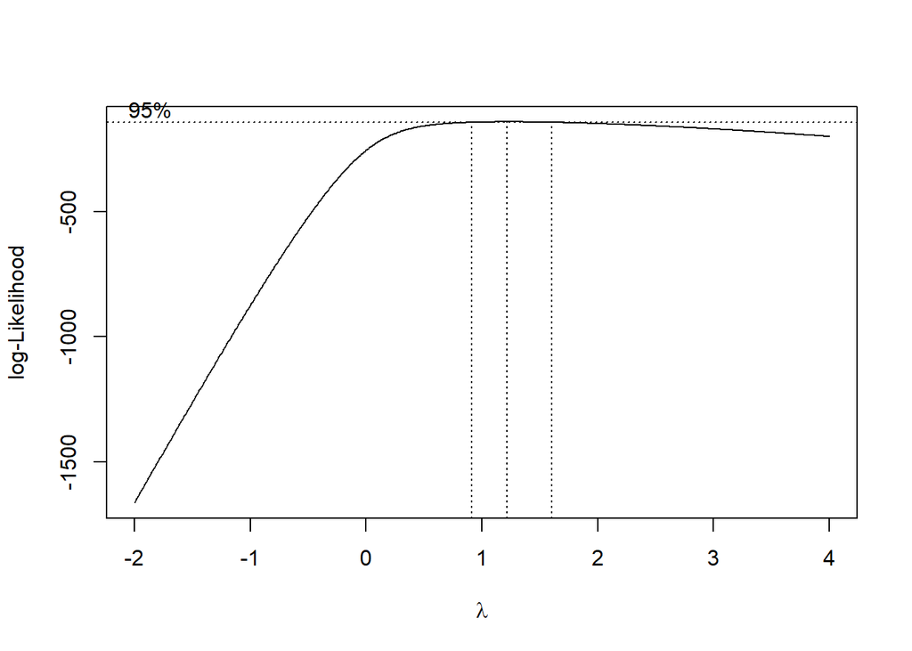

```r
index <- seq_along(diff22_train_geser)

# Plot Box-Cox
bc_train2 <- boxcox(diff22_train_geser ~ index, lambda = seq(-2, 4, by = 0.01))
```

```r
# Nilai lambda maksimum (optimum)
lambda_train2 <- bc_train2$x[which.max(bc_train2$y)]
lambda_train2
```

```
## [1] 1.22
```

```r
# Hitung selang kepercayaan 95%

# CI lambda: nilai log-likelihood maksimum - chi-square
ci_lambda_train2 <- bc_train2$x[bc_train2$y > max(bc_train2$y) - 0.5 * qchisq(0.95, 1)]

# Batas bawah dan atas
ci_lower_train2 <- min(ci_lambda_train2)
ci_upper_train2 <- max(ci_lambda_train2)

# Tampilkan hasil
c(Batas_Bawah2 = ci_lower_train2, Batas_Atas2 = ci_upper_train2)
```

```
## Batas_Bawah2  Batas_Atas2
##         0.92         1.60
```

Gambar di atas menunjukkan nilai λ optimum (rounded value) sebesar 1,22 dan selang kepercayaan 95% nilai memiliki batas bawah 0,92 dan batas atas 1,60. Selang tersebut *memuat nilai satu* sehingga dapat dikatakan bahwa data *stasioner dalam ragam*. Data sudah stasioner dalam ragam dan rataan.

# Spesifikasi Model

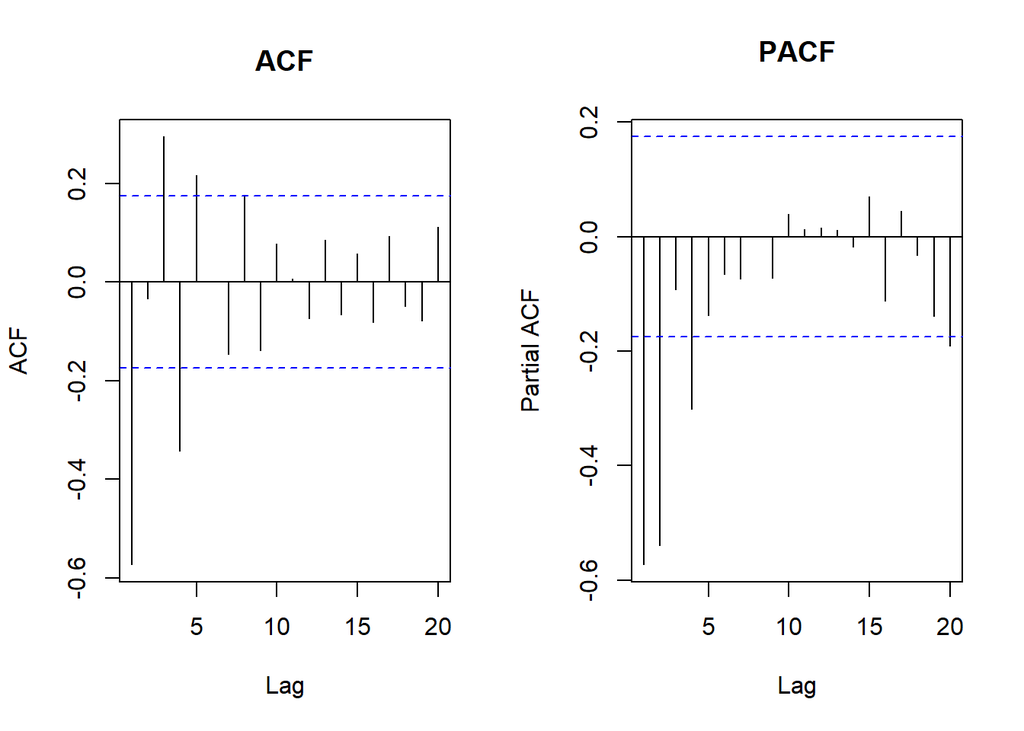

```r
par(mfrow = c(1,2))
acf(diff22_train_geser, main="ACF", lag.max=20)
pacf(diff22_train_geser, main="PACF", lag.max=20)
```

```r
par(mfrow = c(1,1))
```

```r
eacf(diff22_train_geser)
```

```
## AR/MA
##   0 1 2 3 4 5 6 7 8 9 10 11 12 13
## 0 x o x x x o o o o o o  o  o  o
## 1 x o x x x o o o o o o  o  o  o
## 2 o x x o o o o o o o o  o  o  o
## 3 x x x o o o o o o o o  o  o  o
## 4 x o o o o o o o o o o  o  o  o
## 5 x o o o o o o o o o o  o  o  o
## 6 x x o o o x o o o o o  o  o  o
## 7 o x o o o x o o o o o  o  o  o
```

# Pendugaan Parameter

```r
model1.ma2=Arima(diff22_train_geser, order=c(0,2,2),method="ML")
summary(model1.ma2)
```

```
## Series: diff22_train_geser
## ARIMA(0,2,2)
##
## Coefficients:
##           ma1    ma2
##       -1.9935  1.000
## s.e.   0.0302  0.029
##
## sigma^2 = 86692:  log likelihood = -886.55
## AIC=1779.1   AICc=1779.3   BIC=1787.56
##
## Training set error measures:
##                     ME     RMSE     MAE       MPE     MAPE      MASE       ACF1
## Training set -2.295707 289.7244 213.514 -903.6614 918.1088 0.5460157 -0.5617303
```

```r
lmtest::coeftest(model1.ma2)
```

```
##
## z test of coefficients:
##
##      Estimate Std. Error z value  Pr(>|z|)
## ma1 -1.993530   0.030156 -66.108 < 2.2e-16 ***
## ma2  0.999979   0.028995  34.488 < 2.2e-16 ***
## ---
## Signif. codes:  0 '***' 0.001 '**' 0.01 '*' 0.05 '.' 0.1 ' ' 1
```

Seluruh parameter signifikan.

```r
model2.ma2=Arima(diff22_train_geser, order=c(2,2,0),method="ML")
summary(model2.ma2)
```

```
## Series: diff22_train_geser
## ARIMA(2,2,0)
##
## Coefficients:
##           ar1      ar2
##       -1.2735  -0.7660
## s.e.   0.0562   0.0555
##
## sigma^2 = 173398:  log likelihood = -924.12
## AIC=1854.24   AICc=1854.44   BIC=1862.7
##
## Training set error measures:
##                     ME     RMSE      MAE       MPE     MAPE      MASE
## Training set -3.945067 409.7482 311.5277 -1165.088 1187.582 0.7966645
##                    ACF1
## Training set -0.3433832
```

```r
lmtest::coeftest(model2.ma2)
```

```
##
## z test of coefficients:
##
##      Estimate Std. Error z value  Pr(>|z|)
## ar1 -1.273462   0.056187 -22.665 < 2.2e-16 ***
## ar2 -0.765985   0.055517 -13.797 < 2.2e-16 ***
## ---
## Signif. codes:  0 '***' 0.001 '**' 0.01 '*' 0.05 '.' 0.1 ' ' 1
```

```r
model3.ma2=Arima(diff22_train_geser, order=c(0,2,4),method="ML")
summary(model3.ma2)
```

```
## Series: diff22_train_geser
## ARIMA(0,2,4)
##
## Coefficients:
##           ma1     ma2      ma3     ma4
##       -2.9930  3.2086  -1.4328  0.2174
## s.e.   0.0527  0.1673   0.1783  0.0650
##
## sigma^2 = 40692:  log likelihood = -842.48
## AIC=1694.96   AICc=1695.47   BIC=1709.06
##
## Training set error measures:
##                    ME     RMSE      MAE       MPE     MAPE      MASE
## Training set 2.212906 196.8616 151.6784 -375.8717 387.3651 0.3878846
##                     ACF1
## Training set -0.04303892
```

```r
lmtest::coeftest(model3.ma2)
```

```
##
## z test of coefficients:
##
##      Estimate Std. Error  z value  Pr(>|z|)
## ma1 -2.992962   0.052716 -56.7751 < 2.2e-16 ***
## ma2  3.208555   0.167281  19.1807 < 2.2e-16 ***
## ma3 -1.432838   0.178297  -8.0362 9.263e-16 ***
## ma4  0.217351   0.064993   3.3442 0.0008252 ***
## ---
## Signif. codes:  0 '***' 0.001 '**' 0.01 '*' 0.05 '.' 0.1 ' ' 1
```

Semua signifikan.

```r
model4.ma2=Arima(diff22_train_geser, order=c(1,2,4),method="ML")
summary(model4.ma2)
```

```
## Series: diff22_train_geser
## ARIMA(1,2,4)
##
## Coefficients:
##           ar1      ma1     ma2     ma3      ma4
##       -0.8570  -1.8801  0.1324  1.5204  -0.7727
## s.e.   0.1649   0.1466  0.3836  0.3572   0.1214
##
## sigma^2 = 45964:  log likelihood = -846.52
## AIC=1705.05   AICc=1705.76   BIC=1721.97
##
## Training set error measures:
##                    ME     RMSE      MAE       MPE     MAPE      MASE       ACF1
## Training set -4.41967 208.3521 157.0168 -522.0266 533.1054 0.4015365 -0.1897444
```

```r
lmtest::coeftest(model4.ma2)
```

```
##
## z test of coefficients:
##
##     Estimate Std. Error  z value  Pr(>|z|)
## ar1 -0.85699    0.16495  -5.1955 2.042e-07 ***
## ma1 -1.88006    0.14658 -12.8262 < 2.2e-16 ***
## ma2  0.13236    0.38357   0.3451      0.73
## ma3  1.52038    0.35721   4.2563 2.078e-05 ***
## ma4 -0.77268    0.12145  -6.3622 1.989e-10 ***
## ---
## Signif. codes:  0 '***' 0.001 '**' 0.01 '*' 0.05 '.' 0.1 ' ' 1
```

ma2 tidak signifikan.

```r
hasil_model <- data.frame(
  Model = c("ARIMA(0,2,2)",
            "ARIMA(2,2,0)",
            "ARIMA(0,2,4)",
            "ARIMA(1,2,4)"
  ),

  AIC = c(
    AIC(model1.ma2),
    AIC(model2.ma2),
    AIC(model3.ma2),
    AIC(model4.ma2)
  ),

  BIC = c(
    BIC(model1.ma2),
    BIC(model2.ma2),
    BIC(model3.ma2),
    BIC(model4.ma2)
  )
)

hasil_model
```

```
##          Model      AIC      BIC
## 1 ARIMA(0,2,2) 1779.101 1787.561
## 2 ARIMA(2,2,0) 1854.237 1862.698
## 3 ARIMA(0,2,4) 1694.959 1709.060
## 4 ARIMA(1,2,4) 1705.047 1721.969
```

Berdasarkan pendugaan parameter di atas, nilai AIC terkecil dimiliki oleh model ARIMA(0,2,4) dan parameter model ARIMA(0,2,4) juga seluruhnya signifikan sehingga model yang dipilih adalah model ARIMA(0,2,4).

# Analisis Sisaan

## Eksplorasi Sisaan

```
## [1] 72  5
```

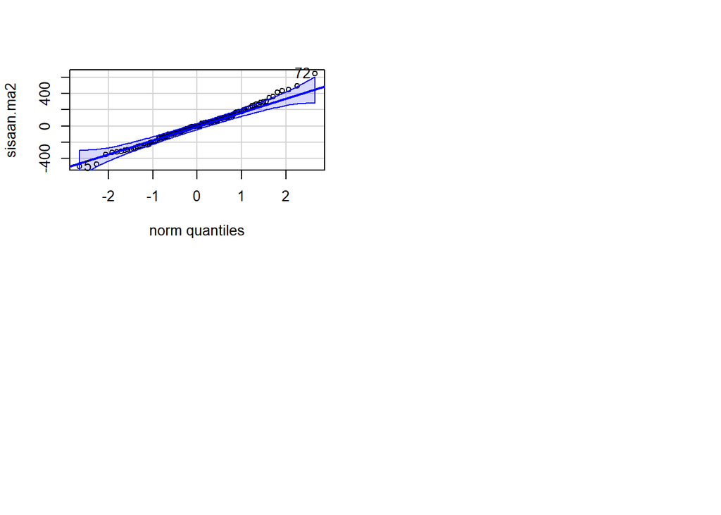

```r
#Eksplorasi
sisaan.ma2 <- model3.ma2$residuals
par(mfrow=c(2,2))

#qqnorm(sisaan.ma2)
#qqline(sisaan.ma2, col = "blue", lwd = 2)
car::qqPlot(sisaan.ma2)
```

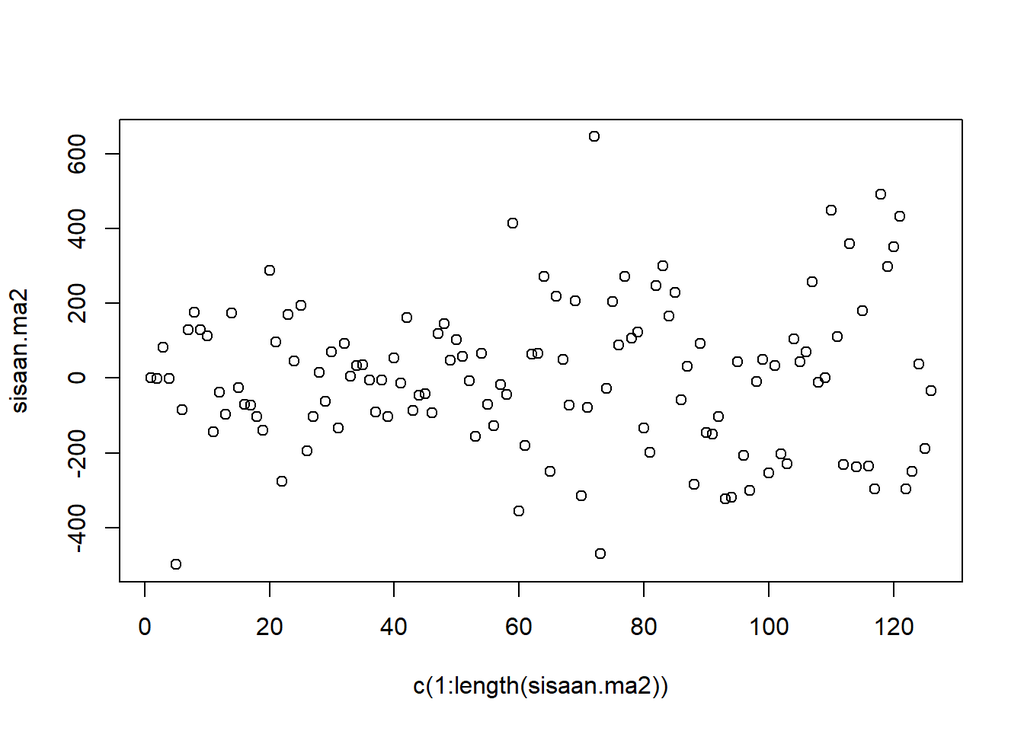

```r
plot(c(1:length(sisaan.ma2)),sisaan.ma2)
```

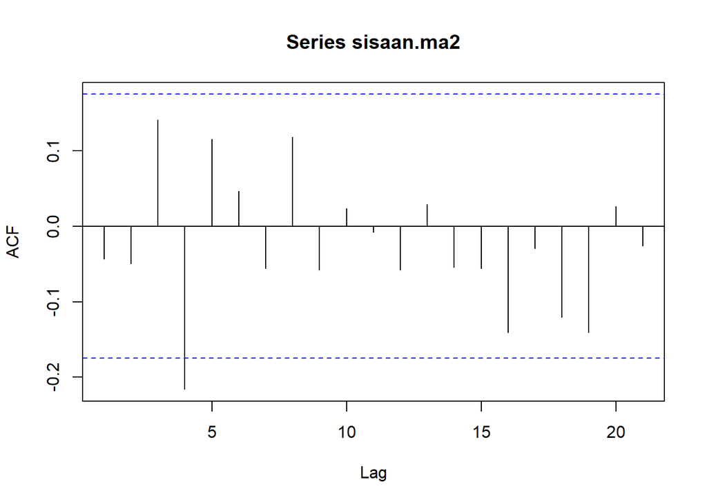

```r
# ACFF dan PACF sisaan
acf(sisaan.ma2)
```

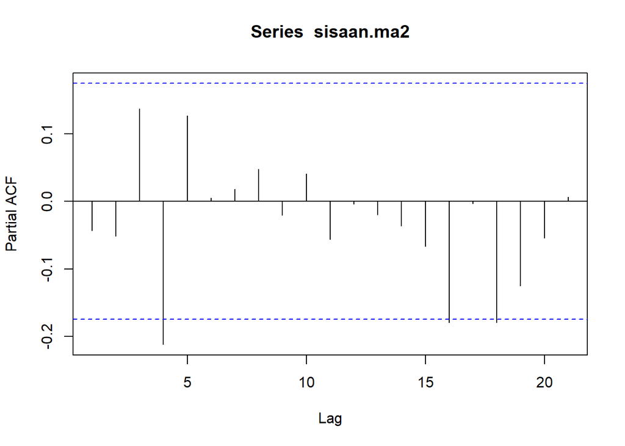

```r
pacf(sisaan.ma2)
```

## Uji Formal

```r
#1) Sisaan Menyebar Normal
ks.test(sisaan.ma2,"pnorm")
```

```
##
##  Asymptotic one-sample Kolmogorov-Smirnov test
##
## data:  sisaan.ma2
## D = 0.49206, p-value < 2.2e-16
## alternative hypothesis: two-sided
```

H0: Sisaan menyebar normal

H1: Sisaan tidak menyebar normal

Berdasarkan uji KS tersebut, didapat p-value < 0,05 sehingga tolak dan menandakan bahwa sisaan tidak menyebar normal. Hal ini tidak sesuai dengan hasil eksplorasi menggunakan plot kuantil-kuantil normal.

```r
#2) Sisaan saling bebas/tidak ada autokorelasi
Box.test(sisaan.ma2, type = "Ljung")
```

```
##
##  Box-Ljung test
##
## data:  sisaan.ma2
## X-squared = 0.239, df = 1, p-value = 0.6249
```

Selanjutnya akan dilakukan uji formal untuk kebebasan sisaan menggunakan uji Ljung-Box. Hipotesis yang digunakan adalah sebagai berikut.

H0: Sisaan saling bebas

H1: Sisaan tidak tidak saling bebas

Berdasarkan uji Ljung-Box tersebut, didapat p-value sebesar 0.6249 yang lebih besar dari taraf nyata 5% sehingga gagal tolak dan menandakan bahwa sisaan saling bebas.

```r
#3) Sisaan homogen
Box.test((sisaan.ma2)^2, type = "Ljung")
```

```
##
##  Box-Ljung test
##
## data:  (sisaan.ma2)^2
## X-squared = 7.8891, df = 1, p-value = 0.004973
```

Hipotesis yang digunakan untuk uji kehomogenan ragam adalah sebagai berikut.

H0: Ragam sisaan homogen

H1: Ragam sisaan tidak homogen

Berdasarkan uji Ljung-Box terhadap sisaan kuadrat tersebut, didapat p-value < 0,05 sehingga tolak dan menandakan bahwa ragam sisaan tidak homogen.

```r
#4) Nilai tengah sisaan sama dengan nol
t.test(sisaan.ma2, mu = 0, conf.level = 0.95)
```

```
##
##  One Sample t-test
##
## data:  sisaan.ma2
## t = 0.12569, df = 125, p-value = 0.9002
## alternative hypothesis: true mean is not equal to 0
## 95 percent confidence interval:
##  -32.63298  37.05880
## sample estimates:
## mean of x
##  2.212906
```

Terakhir, dengan uji-t, akan dicek apakah nilai tengah sisaan sama dengan nol. Hipotesis yang diujikan sebagai berikut.

H0: nilai tengah sisaan sama dengan 0

H1: nilai tengah sisaan tidak sama dengan 0

Berdasarkan uji-ttersebut, didapat p-value sebesar 0.9002 yang lebih besar dari taraf nyata 5% sehingga gagal tolak dan menandakan bahwa nilai tengah sisaan sama dengan nol.

# Overfitting

```r
model3a.ma2=Arima(diff22_train_geser, order=c(0,2,3),method="ML")
summary(model3a.ma2)
```

```
## Series: diff22_train_geser
## ARIMA(0,2,3)
##
## Coefficients:
##           ma1     ma2      ma3
##       -2.7768  2.6305  -0.8537
## s.e.   0.0495  0.0955   0.0483
##
## sigma^2 = 45553:  log likelihood = -847
## AIC=1702   AICc=1702.33   BIC=1713.28
##
## Training set error measures:
##                     ME    RMSE      MAE       MPE     MAPE      MASE      ACF1
## Training set -4.102138 209.153 157.8213 -509.3756 520.5523 0.4035938 -0.164684
```

```r
lmtest::coeftest(model3a.ma2)
```

```
##
## z test of coefficients:
##
##      Estimate Std. Error z value  Pr(>|z|)
## ma1 -2.776762   0.049476 -56.123 < 2.2e-16 ***
## ma2  2.630490   0.095534  27.535 < 2.2e-16 ***
## ma3 -0.853709   0.048333 -17.663 < 2.2e-16 ***
## ---
## Signif. codes:  0 '***' 0.001 '**' 0.01 '*' 0.05 '.' 0.1 ' ' 1
```

```r
model3b.ma2=Arima(diff22_train_geser, order=c(2,2,4),method="ML")
summary(model3b.ma2)
```

```
## Series: diff22_train_geser
## ARIMA(2,2,4)
##
## Coefficients:
##           ar1      ar2      ma1     ma2     ma3      ma4
##       -0.9983  -0.4072  -1.9808  0.5285  0.8996  -0.4468
## s.e.   0.1399   0.0931   0.1740  0.3571  0.4087   0.1721
##
## sigma^2 = 38890:  log likelihood = -838.39
## AIC=1690.79   AICc=1691.75   BIC=1710.53
##
## Training set error measures:
##                    ME     RMSE      MAE       MPE     MAPE      MASE
## Training set 2.009144 190.8415 148.7576 -324.1364 335.6606 0.3804153
##                     ACF1
## Training set 0.002095111
```

```r
lmtest::coeftest(model3b.ma2)
```

```
##
## z test of coefficients:
##
##      Estimate Std. Error  z value  Pr(>|z|)
## ar1 -0.998290   0.139944  -7.1335 9.787e-13 ***
## ar2 -0.407182   0.093096  -4.3738 1.221e-05 ***
## ma1 -1.980826   0.174019 -11.3828 < 2.2e-16 ***
## ma2  0.528452   0.357097   1.4799   0.13891
## ma3  0.899609   0.408707   2.2011   0.02773 *
## ma4 -0.446812   0.172111  -2.5961   0.00943 **
## ---
## Signif. codes:  0 '***' 0.001 '**' 0.01 '*' 0.05 '.' 0.1 ' ' 1
```

ma2 tidak signifikan.

```r
overfitting <- data.frame(
  Model = c("ARIMA(0,2,3)","ARIMA(0,2,4)", "ARIMA(2,2,4)"),
  AIC   = c(AIC(model3a.ma2),AIC(model3.ma2), AIC(model3b.ma2)),
  BIC   = c(BIC(model3a.ma2),BIC(model3.ma2), BIC(model3b.ma2))
)

overfitting
```

```
##          Model      AIC      BIC
## 1 ARIMA(0,2,3) 1701.997 1713.278
## 2 ARIMA(0,2,4) 1694.959 1709.060
## 3 ARIMA(2,2,4) 1690.785 1710.527
```

# Peramalan

```r
#---FORECAST---#
ramalan <- forecast::forecast(model3b.ma2, h = 32)
ramalan
```

```
##     Point Forecast    Lo 80    Hi 80    Lo 95    Hi 95
## 127       1135.493 882.3725 1388.613 748.3786 1522.607
## 128       1071.608 717.9093 1425.307 530.6724 1612.544
## 129       1182.920 827.5236 1538.316 639.3883 1726.451
## 130       1097.743 735.5314 1459.954 543.7883 1651.698
## 131       1137.382 766.4713 1508.292 570.1231 1704.641
## 132       1132.425 757.3947 1507.455 558.8657 1705.984
## 133       1121.165 745.6781 1496.652 546.9075 1695.422
## 134       1134.356 758.8695 1509.842 560.0990 1708.613
## 135       1125.704 750.0353 1501.373 551.1682 1700.240
## 136       1128.902 753.1641 1504.639 554.2606 1703.543
## 137       1129.164 753.3589 1504.969 554.4197 1703.909
## 138       1127.532 751.7268 1503.337 552.7877 1702.276
## 139       1128.986 753.1792 1504.793 554.2390 1703.733
## 140       1128.131 752.3091 1503.952 553.3611 1702.900
```

[output cut: 18 more lines]

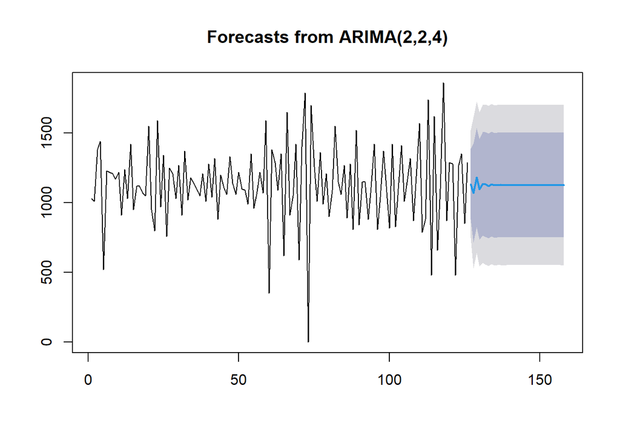

```r
data.ramalan <- ramalan$mean
plot(ramalan)
```

Berdasarkan hasil plot ramalan di atas, dapat dilihat bahwa ramalan ARIMA(2,2,4) cenderung fultuatif di awal periode dan stabil hingga akhir periode. Selanjutnya, dapat dicari nilai akurasi antara hasil ramalan dengan data uji sebagai berikut.

```r
perbandingan<-matrix(data=c(test_data$Jawa.Barat, data.ramalan),
                     nrow = 32, ncol = 2)
colnames(perbandingan)<-c("Aktual","Hasil Forecast")
perbandingan
```

```
##       Aktual Hasil Forecast
##  [1,]  28200       1135.493
##  [2,]  28310       1071.608
##  [3,]  28240       1182.920
##  [4,]  28250       1097.743
##  [5,]  28390       1137.382
##  [6,]  28270       1132.425
##  [7,]  28160       1121.165
##  [8,]  28400       1134.356
##  [9,]  28580       1125.704
## [10,]  28660       1128.902
## [11,]  28690       1129.164
## [12,]  29170       1127.532
## [13,]  29340       1128.986
## [14,]  29460       1128.131
```

[output cut: 18 more lines]

```r
# Akurasi
accuracy(data.ramalan, test_data$Jawa.Barat)
```

```
##                ME  RMSE      MAE      MPE     MAPE
## Test set 29078.52 29121 29078.52 96.25648 96.25648
```

> MAPE = 96.26% berarti rata-rata ramalan salah sebesar 96.26% dari nilai sebenarnya.

> Ini menunjukkan bahwa model kurang akurat, dan hasil ramalan tidak bisa digunakan untuk pengambilan keputusan.

> Nilai error lainnya (MAE dan RMSE) juga besar, menandakan deviasi yang tinggi antara nilai aktual dan prediksi.